# Manuscript Tables and Figures

B Steele, Colorado State University, ROSSyndicate

last updated Sep 24, 2026

Tables and figures for the regional Secchi disc depth manuscript, built from the outputs of the numbered workflow scripts. Each table is also written as a .csv to `regional_clarity/manuscript/` for pasting into the manuscript.

## Setup

```r
library(arrow)
library(jsonlite)
library(tidyverse)

filtered_aquamatch_dir <- "regional_clarity/aquamatch_files"
models_dir <- "regional_clarity/xg_models/v3_production"
manuscript_dir <- "regional_clarity/manuscript"
ensemble_seeds <- 601:610
dir.create(manuscript_dir, showWarnings = FALSE)
```

## Figures

### Figure 3: holdout performance, feature attribution, application record

```r
application_dir <- file.path(filtered_aquamatch_dir, "application")

filter_steps <- read_csv(file.path(application_dir, "application_filter_steps.csv"), show_col_types = FALSE)
rs_estimates <- read_parquet(file.path(application_dir, "application_rs_estimates.parquet"))
insitu_days <- read_parquet(file.path(application_dir, "application_insitu_location_days.parquet"))
superseded_validation <- read_csv(file.path(application_dir, "superseded_validation.csv"), show_col_types = FALSE) %>%
  filter(sites == "all sites")
aoa_params <- read_json(file.path(application_dir, "aoa_parameters.json"))

# remote sensing estimates on days with no in situ observation at that location
rs_new <- anti_join(rs_estimates, insitu_days, by = c("location_id", "date"))
combined_days <- bind_rows(select(insitu_days, location_id, date),
                           select(rs_estimates, location_id, date)) %>%
  distinct()

per_location <- full_join(count(insitu_days, location_id, name = "n_insitu"),
                          count(rs_new, location_id, name = "n_rs_new"),
                          by = "location_id") %>%
  mutate(across(c(n_insitu, n_rs_new), ~ replace_na(.x, 0L)))

location_years <- function(df) nrow(distinct(df, location_id, year = year(date)))

application_summary <- list(
  n_insitu_locations = n_distinct(insitu_days$location_id),
  n_insitu_days = nrow(insitu_days),
  n_rs_locations = n_distinct(rs_estimates$location_id),
  n_rs_days = nrow(rs_estimates),
  n_rs_new = nrow(rs_new),
  n_combined = nrow(combined_days),
  fold_increase = nrow(combined_days) / nrow(insitu_days),
  insitu_location_years = location_years(insitu_days),
  combined_location_years = location_years(combined_days),
  # among locations with at least one remote sensing estimate
  median_location_multiplier = per_location %>%
    filter(n_rs_new > 0) %>%
    summarise(m = median((n_insitu + n_rs_new) / pmax(n_insitu, 1))) %>%
    pull(m),
  season_window = as.Date(unlist(aoa_params$season_window_doy) - 1, origin = "2021-01-01"),
  superseded_share_applicable = superseded_validation$n[superseded_validation$group == "passes all checks"] /
    superseded_validation$n[superseded_validation$group == "all superseded"]
)
str(application_summary)
```

```
## List of 12
##  $ n_insitu_locations         : int 2373
##  $ n_insitu_days              : int 28389
##  $ n_rs_locations             : int 1796
##  $ n_rs_days                  : int 660458
##  $ n_rs_new                   : int 659452
##  $ n_combined                 : int 687841
##  $ fold_increase              : num 24.2
##  $ insitu_location_years      : int 9826
##  $ combined_location_years    : int 71966
##  $ median_location_multiplier : num 84
##  $ season_window              : Date[1:2], format: "2021-03-11" "2021-11-16"
##  $ superseded_share_applicable: num 0.965
```

Filtering from siteSR observations to usable SDD estimates

```r
application_table <- filter_steps %>%
  select(Step = step, `Location-days` = location_days, Locations = locations) %>%
  bind_rows(tibble(Step = c("In situ SDD (for comparison)",
                            "Remote sensing estimates on days without in situ SDD",
                            "Combined in situ + remote sensing"),
                   `Location-days` = c(application_summary$n_insitu_days,
                                       application_summary$n_rs_new,
                                       application_summary$n_combined),
                   Locations = c(application_summary$n_insitu_locations,
                                 n_distinct(rs_new$location_id),
                                 n_distinct(combined_days$location_id))))

write_csv(application_table, file.path(manuscript_dir, "table_application_filtering.csv"))

knitr::kable(application_table,
             caption = paste("Landsat observations at regional locations with quality-controlled in situ SDD,",
                             "counted as distinct location-days after each filtering step required for a",
                             "trustworthy SDD estimate, compared with the in situ record at the same locations."),
             format.args = list(big.mark = ","))
```

Landsat observations at regional locations with quality-controlled in situ SDD, counted as distinct location-days after each filtering step required for a trustworthy SDD estimate, compared with the in situ record at the same locations.

| Step | Location-days | Locations |
| --- | --- | --- |
| siteSR observations (before QA) | 1,467,744 | 2,159 |
| After siteSR QA | 746,489 | 1,826 |
| Landsat mission represented in training | 746,489 | 1,826 |
| Within seasonal window of training matchups | 691,829 | 1,826 |
| All model inputs available | 691,809 | 1,826 |
| Within training range of every input | 680,269 | 1,798 |
| Inside area of applicability | 662,289 | 1,796 |
| Estimate no shallower than training minimum | 660,458 | 1,796 |
| In situ SDD (for comparison) | 28,389 | 2,373 |
| Remote sensing estimates on days without in situ SDD | 659,452 | 1,796 |
| Combined in situ + remote sensing | 687,841 | 2,373 |

Panel a: the production ensemble’s holdout predictions, read from each seed’s `holdout_predictions.parquet` and averaged per (site, date) exactly as in `05_evaluate_ensemble.ipynb` (across all 40 members and any same-day matchups from different missions). Metrics match `python/metrics.py` (R² is the squared Pearson correlation) and go in the caption rather than the plot. Panel b: ensemble-mean |SHAP| over the unanimous core features, written by `05_evaluate_ensemble.ipynb` to `ensemble_mean_abs_shap.csv`.

Panel c: How many more SDD observations does remote sensing provide at the locations where in situ SDD is already collected? `07_regional_application.Rmd` applies the production ensemble to every Landsat observation at every regional location with QC’d in situ SDD, then keeps only estimates that pass the same checks that would be needed to trust them: siteSR QA identical to the training data, a Landsat mission represented in training, the seasonal window of the training matchups, complete model inputs, every input within the training range, the model’s area of applicability (AOA; Meyer & Pebesma 2021), and a physically plausible estimate. Everything here is counted in *location-days*: distinct (physical location, date) pairs, where sites within 100 m on the same waterbody are one location. That way neither a station listed under two identifiers nor overlapping Landsat paths on the same day inflates either side of the comparison.

```r
holdout_preds <- map(ensemble_seeds, \(s) {
  read_parquet(file.path(models_dir, paste0("seed", s), "holdout_predictions.parquet"))
}) %>%
  list_rbind() %>%
  summarise(obs = first(y), pred = mean(pred), .by = c(siteSR_id, date))

holdout_metrics <- holdout_preds %>%
  summarise(n = n(),
            rmse = sqrt(mean((obs - pred)^2)),
            mae = mean(abs(obs - pred)),
            bias = mean(pred - obs),
            r2 = cor(obs, pred)^2)

mean_abs_shap <- read_csv(file.path(models_dir, "ensemble_mean_abs_shap.csv"),
                          show_col_types = FALSE)

feature_labels <- c(
  BG = "Blue:green ratio",
  green_corr7 = "Green reflectance",
  BR = "Blue:red ratio",
  MNDWI = "MNDWI",
  fai = "Floating algae index",
  catchment_area_sqkm = "Catchment area",
  NR = "NIR:red ratio",
  srad_Wm2_prev30 = "Solar radiation, 30-d mean",
  srad_Wm2_prev7 = "Solar radiation, 7-d mean",
  srad_Wm2_prev1 = "Solar radiation, previous day",
  tmean_degC_prev30 = "Air temperature, 30-d mean",
  tmax_degC_prev30 = "Air temperature, 30-d max",
  nir_corr7 = "NIR reflectance",
  temp_corr7 = "Surface temperature",
  NDVI = "NDVI",
  NDWI = "NDWI",
  NDSSI = "NDSSI",
  atm_corr_LaSRC = "Atmospheric correction (LaSRC)",
  shore_flag = "Near-shore flag",
  pct_impervious_2006 = "Catchment impervious (%)",
  pct_wetland_2006 = "Catchment wetland (%)"
)
category_labels <- c(optical = "Optical", site = "Site/catchment", weather = "Antecedent weather")
category_colors <- c("Optical" = "#002EA3", "Site/catchment" = "#E70870", "Antecedent weather" = "#256BF5")

stopifnot("SHAP feature missing a display label" = all(mean_abs_shap$feature %in% names(feature_labels)))

mean_abs_shap <- mean_abs_shap %>%
  mutate(label = fct_reorder(feature_labels[feature], mean_abs_shap),
         Category = factor(category_labels[category], levels = category_labels))

category_share <- mean_abs_shap %>%
  summarise(share = sum(mean_abs_shap), .by = Category) %>%
  mutate(share = 100 * share / sum(share))
```

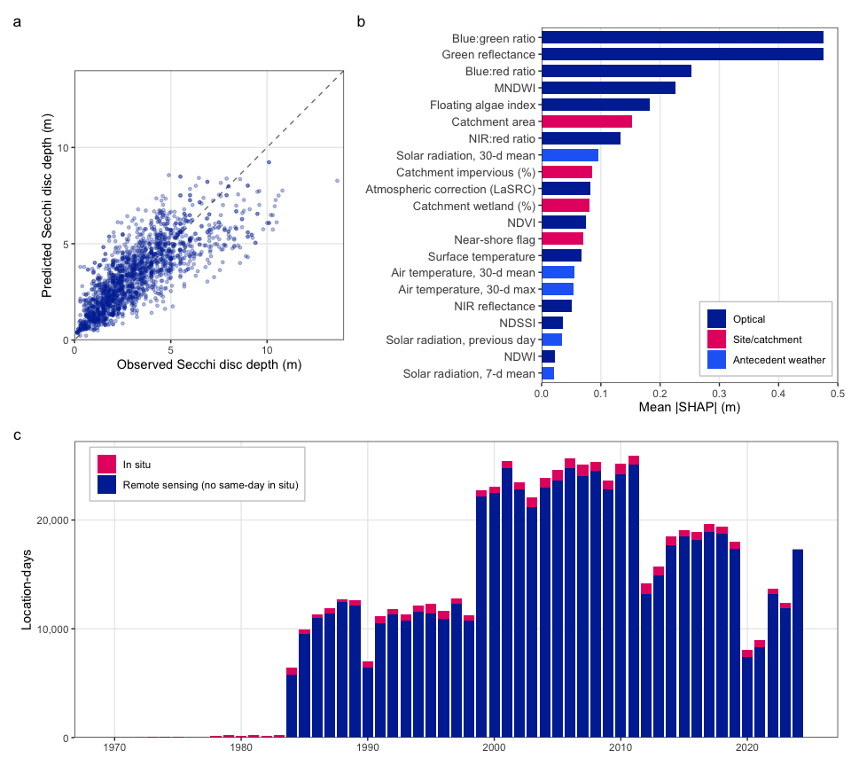

```r
axis_max <- ceiling(max(holdout_preds$obs, holdout_preds$pred))

pred_obs <- ggplot(holdout_preds, aes(obs, pred)) +
  geom_abline(slope = 1, intercept = 0, linetype = "dashed", color = "grey50") +
  geom_point(alpha = 0.3, size = 1, color = "#002EA3") +
  coord_equal(xlim = c(0, axis_max), ylim = c(0, axis_max), expand = FALSE) +
  labs(x = "Observed Secchi disc depth (m)", y = "Predicted Secchi disc depth (m)") +
  theme_bw() +
  theme(panel.grid.minor = element_blank())

shap_bars <- ggplot(mean_abs_shap, aes(mean_abs_shap, label, fill = Category)) +
  geom_col(width = 0.75) +
  scale_fill_manual(values = category_colors, name = NULL) +
  scale_x_continuous(expand = expansion(mult = c(0, 0.05))) +
  labs(x = "Mean |SHAP| (m)", y = NULL) +
  theme_bw() +
  theme(panel.grid.major.y = element_blank(),
        panel.grid.minor = element_blank(),
        axis.text.y = element_text(size = 10),
        legend.position = "inside",
        legend.position.inside = c(0.98, 0.02),
        legend.justification = c(1, 0),
        legend.background = element_rect(fill = "white", color = "grey80"))

annual <- bind_rows(insitu_days %>% mutate(source = "In situ"),
                    rs_new %>% mutate(source = "Remote sensing (no same-day in situ)")) %>%
  count(source, year = year(date))

annual_panel <- ggplot(annual, aes(year, n, fill = source)) +
  geom_col(width = 0.85) +
  scale_fill_manual(values = c("In situ" = "#E70870", "Remote sensing (no same-day in situ)" = "#002EA3"),
                    name = NULL) +
  scale_y_continuous(labels = scales::label_comma(), expand = expansion(mult = c(0, 0.05))) +
  labs(x = NULL, y = "Location-days") +
  theme_bw() +
  theme(panel.grid.minor = element_blank(),
        legend.position = "inside",
        legend.position.inside = c(0.02, 0.98),
        legend.justification = c(0, 1),
        legend.background = element_rect(fill = "white", color = "grey80"))

figure_3 <- patchwork::wrap_plots(pred_obs, shap_bars, annual_panel,
                                  design = "AB\nCC", widths = c(1, 1.1), heights = c(1.2, 1)) +
  patchwork::plot_annotation(tag_levels = "a")

ggsave(file.path(manuscript_dir, "figure_3.png"), figure_3, width = 10, height = 9, dpi = 300)

figure_3
```

**Figure 3.** (a) Predicted versus observed Secchi disc depth (SDD) for the held-out test set (n = 1,833 site-date matchups), where each prediction is the mean of the 40-member ensemble; the dashed line is 1:1. RMSE = 1.26 m, MAE = 0.94 m, bias = +0.15 m, R² = 0.63. (b) Mean absolute SHAP value for each of the 21 features selected by all ten ensemble seeds, averaged across the 40-member ensemble and the test set, colored by feature category: optical (dark blue; 76% of total attribution), site/catchment (pink; 14%), and antecedent weather (light blue; 10%). (c) Annual SDD location-days at the 2,373 regional locations with quality-controlled in situ SDD: in situ observations (pink) and remote sensing estimates on days without a same-day in situ observation (dark blue; n = 659,452). Remote sensing estimates are those passing siteSR QA, the seasonal window of the training matchups, complete model inputs, the training range of every input, the model’s area of applicability (Meyer & Pebesma 2021), and a physically plausible estimate.

## Supplemental

### Supplemental Table 1: Data reduction through the filtering pipeline

SDD and siteSR counts come from the row log written by `01_filter_AquaMatch_Data.Rmd`. Matched counts are taken directly from the parquet outputs of `02_make_matches.Rmd` so they always reflect the matchup data the models were trained on. The rain-screened candidate pool is the final closest-observation set plus the non-closest candidates set aside after closest-in-time selection.

```r
row_log_01 <- read_csv(file.path(filtered_aquamatch_dir, "row_loss_log_01.csv"),
                       show_col_types = FALSE)

match_5d <- read_parquet(file.path(filtered_aquamatch_dir, "sdd_regional_siteSR_matchups_5d.parquet"))
match_closest <- read_parquet(file.path(filtered_aquamatch_dir, "filtered_regional_sdd.parquet"))
match_not_closest <- read_parquet(file.path(filtered_aquamatch_dir, "regional_sdd_not_closest.parquet"))
match_rain_screened <- bind_rows(match_closest, match_not_closest)

row_log_matched <- tibble(
  pipeline = "matched",
  step = c("0_5day_window_match", "1_heavy_rain_screen", "2_closest_observation_final"),
  n_rows = c(nrow(match_5d), nrow(match_rain_screened), nrow(match_closest)),
  n_sites = c(n_distinct(match_5d$siteSR_id), n_distinct(match_rain_screened$siteSR_id),
              n_distinct(match_closest$siteSR_id))
)
```

```r
step_labels <- c(
  "0_raw_nationwide" = "Raw nationwide",
  "1_quality_tier_flag_filters" = "Tier/flag QC filters",
  "2_regional_HUC4_restriction" = "Regional HUC4 restriction",
  "3_ransac_inliers_for_matching" = "RANSAC inliers",
  "1_geometry_and_HUC4_scoped" = "Geometry and regional HUC4 restriction",
  "2_metadata_scene_QA" = "Metadata/scene QA",
  "3_band_ransac_filter_final" = "RANSAC inliers",
  "0_5day_window_match" = "±5-day window match",
  "1_heavy_rain_screen" = "Heavy rain screen",
  "2_closest_observation_final" = "Closest observation (final)"
)

data_reduction <- bind_rows(row_log_01, row_log_matched) %>%
  mutate(Pipeline = factor(pipeline, levels = c("SDD", "siteSR", "matched"),
                           labels = c("SDD", "siteSR", "Matched")),
         Step = step_labels[step]) %>%
  arrange(Pipeline, step) %>%
  select(Pipeline, Step, Rows = n_rows, Sites = n_sites)

stopifnot(!anyNA(data_reduction$Step))

write_csv(data_reduction, file.path(manuscript_dir, "supp_table_1_data_reduction.csv"), na = "")

knitr::kable(data_reduction,
             caption = "Data reduction at each step of the filtering process leading up to developing the model to estimate Secchi disc depth across our six-state region.",
             format.args = list(big.mark = ","))
```

Data reduction at each step of the filtering process leading up to developing the model to estimate Secchi disc depth across our six-state region.

| Pipeline | Step | Rows | Sites |
| --- | --- | --- | --- |
| SDD | Raw nationwide | 2,739,358 | NA |
| SDD | Tier/flag QC filters | 1,654,029 | 67,369 |
| SDD | Regional HUC4 restriction | 35,374 | 2,783 |
| SDD | RANSAC inliers | 35,183 | 2,783 |
| siteSR | Raw nationwide | 167,472,586 | 342,704 |
| siteSR | Geometry and regional HUC4 restriction | 7,381,846 | 10,369 |
| siteSR | Metadata/scene QA | 4,510,842 | 9,961 |
| siteSR | RANSAC inliers | 4,318,743 | 9,961 |
| Matched | ±5-day window match | 13,980 | 1,462 |
| Matched | Heavy rain screen | 13,954 | 1,462 |
| Matched | Closest observation (final) | 11,143 | 1,462 |

### Supplemental Table 2: candidate features

Candidate features and their fate through feature selection in `04_make_models.ipynb`. The candidate list, correlation-pruned list, and each seed’s final feature set are read from each seed’s `backward_elim_summary.json`. Correlation pruning is deterministic across seeds (all seeds share the same CV pool), so a single pruned set is reported. Descriptions are written by hand here and checked against the candidate list so a feature added or removed upstream fails loudly rather than silently.

```r
seed_elim <- map(ensemble_seeds, \(s) {
  read_json(file.path(models_dir, paste0("seed", s), "backward_elim_summary.json"),
            simplifyVector = TRUE)
}) %>%
  set_names(ensemble_seeds)

candidates <- seed_elim[[1]]$starting_candidates
pruned <- seed_elim[[1]]$correlation_pruned

stopifnot("candidate lists differ across seeds" =
            all(map_lgl(seed_elim, \(x) setequal(x$starting_candidates, candidates))),
          "correlation-pruned lists differ across seeds" =
            all(map_lgl(seed_elim, \(x) setequal(x$correlation_pruned, pruned))))

n_seeds_selected <- map(seed_elim, "final_features") %>%
  unlist() %>%
  table() %>%
  c()
```

```r
weather_desc <- function(var, w) {
  day_txt <- if (w == 1) "the day" else paste(w, "days")
  switch(var,
         precip_mm = paste0("Total precipitation over ", day_txt, " before the matchup (mm)"),
         tmax_degC = paste0("Maximum daily maximum air temperature over ", day_txt, " before the matchup (°C)"),
         tmin_degC = paste0("Minimum daily minimum air temperature over ", day_txt, " before the matchup (°C)"),
         tmean_degC = paste0("Mean daily air temperature over ", day_txt, " before the matchup (°C)"),
         srad_Wm2 = paste0("Mean daily shortwave radiation over ", day_txt, " before the matchup (W m⁻²)"))
}

weather_feats <- expand_grid(var = c("precip_mm", "tmax_degC", "tmean_degC", "tmin_degC", "srad_Wm2"),
                             w = c(1, 3, 7, 30)) %>%
  mutate(Feature = paste0(var, "_prev", w),
         Description = map2_chr(var, w, weather_desc),
         Category = "Antecedent weather",
         Source = "gridMET")

band_src <- "Landsat C2 SR, harmonized to Landsat 7 (Gardner et al.)"
feature_desc <- tribble(
  ~Feature, ~Category, ~Description, ~Source,
  "blue_corr7", "Optical", "Blue surface reflectance", band_src,
  "green_corr7", "Optical", "Green surface reflectance", band_src,
  "red_corr7", "Optical", "Red surface reflectance", band_src,
  "nir_corr7", "Optical", "Near-infrared surface reflectance", band_src,
  "swir1_corr7", "Optical", "Shortwave infrared 1 surface reflectance", band_src,
  "swir2_corr7", "Optical", "Shortwave infrared 2 surface reflectance", band_src,
  "temp_corr7", "Optical", "Surface temperature", band_src,
  "atm_corr_LaSRC", "Optical", "Atmospheric correction algorithm (1 = LaSRC, Landsat 8/9; 0 = LEDAPS, Landsat 4/5/7)", "Landsat mission",
  "BR", "Optical", "Blue:red ratio", "Derived",
  "BG", "Optical", "Blue:green ratio", "Derived",
  "NR", "Optical", "Near-infrared:red ratio", "Derived",
  "GR", "Optical", "Green:red ratio", "Derived",
  "fai", "Optical", "Floating algae index", "Derived",
  "NDVI", "Optical", "Normalized difference vegetation index, (NIR − red)/(NIR + red)", "Derived",
  "NDSSI", "Optical", "Normalized difference suspended sediment index, (blue − NIR)/(blue + NIR)", "Derived",
  "NDWI", "Optical", "Normalized difference water index, (green − NIR)/(green + NIR) (McFeeters 1996)", "Derived",
  "MNDWI", "Optical", "Modified NDWI, (green − SWIR1)/(green + SWIR1) (Xu 2006)", "Derived",
  "elevation_m", "Site/catchment", "Site elevation (m)", "AWS terrain tiles",
  "catchment_area_sqkm", "Site/catchment", "Local catchment area (km², winsorized at 617 km² and log-binned)", "LakeCat",
  "pct_impervious_2006", "Site/catchment", "Catchment impervious surface (%, 2006)", "LakeCat",
  "pct_urban_2006", "Site/catchment", "Catchment developed land cover (%, 2006)", "LakeCat",
  "pct_forest_2006", "Site/catchment", "Catchment forest land cover (%, 2006)", "LakeCat",
  "pct_cropland_2006", "Site/catchment", "Catchment cropland land cover (%, 2006)", "LakeCat",
  "pct_wetland_2006", "Site/catchment", "Catchment wetland land cover (%, 2006)", "LakeCat",
  "shore_flag", "Site/catchment", "Site within 230 m of shoreline or outside its matched waterbody polygon (1 = yes)", "siteSR QA flags"
) %>%
  bind_rows(select(weather_feats, Feature, Category, Description, Source))

stopifnot("candidate features missing a description" = all(candidates %in% feature_desc$Feature))
```

```r
supp_table_2 <- feature_desc %>%
  filter(Feature %in% candidates) %>%
  mutate(Category = factor(Category, levels = c("Optical", "Site/catchment", "Antecedent weather")),
         `Retained after correlation pruning` = if_else(Feature %in% pruned, "Yes", "No"),
         `Seeds selecting (of 10)` = as.integer(coalesce(n_seeds_selected[Feature], 0L))) %>%
  arrange(Category, match(Feature, candidates)) %>%
  select(Category, Feature, Description, Source,
         `Retained after correlation pruning`, `Seeds selecting (of 10)`)

write_csv(supp_table_2, file.path(manuscript_dir, "supp_table_2_candidate_features.csv"))

knitr::kable(supp_table_2,
             caption = paste0("Candidate features considered for the Secchi disc depth model (n = ",
                              length(candidates), "). Features were first reduced by correlation pruning (|r| > 0.95; ",
                              length(pruned), " retained), then each of the 10 ensemble seeds performed its own ",
                              "backward elimination. Features selected by all 10 seeds (n = ",
                              sum(supp_table_2$`Seeds selecting (of 10)` == 10),
                              ") form the common core used for SHAP attribution."))
```

Candidate features considered for the Secchi disc depth model (n = 45). Features were first reduced by correlation pruning (|r| > 0.95; 34 retained), then each of the 10 ensemble seeds performed its own backward elimination. Features selected by all 10 seeds (n = 21) form the common core used for SHAP attribution.

| Category | Feature | Description | Source | Retained after correlation pruning | Seeds selecting (of 10) |
| --- | --- | --- | --- | --- | --- |
| Optical | atm_corr_LaSRC | Atmospheric correction algorithm (1 = LaSRC, Landsat 8/9; 0 = LEDAPS, Landsat 4/5/7) | Landsat mission | Yes | 10 |
| Optical | red_corr7 | Red surface reflectance | Landsat C2 SR, harmonized to Landsat 7 (Gardner et al.) | No | 0 |
| Optical | green_corr7 | Green surface reflectance | Landsat C2 SR, harmonized to Landsat 7 (Gardner et al.) | Yes | 10 |
| Optical | blue_corr7 | Blue surface reflectance | Landsat C2 SR, harmonized to Landsat 7 (Gardner et al.) | No | 0 |
| Optical | nir_corr7 | Near-infrared surface reflectance | Landsat C2 SR, harmonized to Landsat 7 (Gardner et al.) | Yes | 10 |
| Optical | swir1_corr7 | Shortwave infrared 1 surface reflectance | Landsat C2 SR, harmonized to Landsat 7 (Gardner et al.) | Yes | 8 |
| Optical | swir2_corr7 | Shortwave infrared 2 surface reflectance | Landsat C2 SR, harmonized to Landsat 7 (Gardner et al.) | No | 0 |
| Optical | temp_corr7 | Surface temperature | Landsat C2 SR, harmonized to Landsat 7 (Gardner et al.) | Yes | 10 |
| Optical | BR | Blue:red ratio | Derived | Yes | 10 |
| Optical | BG | Blue:green ratio | Derived | Yes | 10 |
| Optical | NR | Near-infrared:red ratio | Derived | Yes | 10 |
| Optical | GR | Green:red ratio | Derived | No | 0 |
| Optical | fai | Floating algae index | Derived | Yes | 10 |
| Optical | NDVI | Normalized difference vegetation index, (NIR − red)/(NIR + red) | Derived | Yes | 10 |
| Optical | NDSSI | Normalized difference suspended sediment index, (blue − NIR)/(blue + NIR) | Derived | Yes | 10 |
| Optical | NDWI | Normalized difference water index, (green − NIR)/(green + NIR) (McFeeters 1996) | Derived | Yes | 10 |
| Optical | MNDWI | Modified NDWI, (green − SWIR1)/(green + SWIR1) (Xu 2006) | Derived | Yes | 10 |
| Site/catchment | elevation_m | Site elevation (m) | AWS terrain tiles | Yes | 2 |
| Site/catchment | catchment_area_sqkm | Local catchment area (km², winsorized at 617 km² and log-binned) | LakeCat | Yes | 10 |
| Site/catchment | pct_impervious_2006 | Catchment impervious surface (%, 2006) | LakeCat | Yes | 10 |
| Site/catchment | pct_urban_2006 | Catchment developed land cover (%, 2006) | LakeCat | Yes | 8 |
| Site/catchment | pct_forest_2006 | Catchment forest land cover (%, 2006) | LakeCat | Yes | 9 |
| Site/catchment | pct_cropland_2006 | Catchment cropland land cover (%, 2006) | LakeCat | Yes | 9 |
| Site/catchment | pct_wetland_2006 | Catchment wetland land cover (%, 2006) | LakeCat | Yes | 10 |
| Site/catchment | shore_flag | Site within 230 m of shoreline or outside its matched waterbody polygon (1 = yes) | siteSR QA flags | Yes | 10 |
| Antecedent weather | precip_mm_prev1 | Total precipitation over the day before the matchup (mm) | gridMET | Yes | 8 |
| Antecedent weather | tmax_degC_prev1 | Maximum daily maximum air temperature over the day before the matchup (°C) | gridMET | No | 0 |
| Antecedent weather | tmean_degC_prev1 | Mean daily air temperature over the day before the matchup (°C) | gridMET | No | 0 |
| Antecedent weather | tmin_degC_prev1 | Minimum daily minimum air temperature over the day before the matchup (°C) | gridMET | No | 0 |
| Antecedent weather | srad_Wm2_prev1 | Mean daily shortwave radiation over the day before the matchup (W m⁻²) | gridMET | Yes | 10 |
| Antecedent weather | precip_mm_prev3 | Total precipitation over 3 days before the matchup (mm) | gridMET | Yes | 4 |
| Antecedent weather | tmax_degC_prev3 | Maximum daily maximum air temperature over 3 days before the matchup (°C) | gridMET | No | 0 |
| Antecedent weather | tmean_degC_prev3 | Mean daily air temperature over 3 days before the matchup (°C) | gridMET | No | 0 |
| Antecedent weather | tmin_degC_prev3 | Minimum daily minimum air temperature over 3 days before the matchup (°C) | gridMET | No | 0 |
| Antecedent weather | srad_Wm2_prev3 | Mean daily shortwave radiation over 3 days before the matchup (W m⁻²) | gridMET | No | 0 |
| Antecedent weather | precip_mm_prev7 | Total precipitation over 7 days before the matchup (mm) | gridMET | Yes | 4 |
| Antecedent weather | tmax_degC_prev7 | Maximum daily maximum air temperature over 7 days before the matchup (°C) | gridMET | Yes | 3 |
| Antecedent weather | tmean_degC_prev7 | Mean daily air temperature over 7 days before the matchup (°C) | gridMET | Yes | 7 |
| Antecedent weather | tmin_degC_prev7 | Minimum daily minimum air temperature over 7 days before the matchup (°C) | gridMET | Yes | 4 |
| Antecedent weather | srad_Wm2_prev7 | Mean daily shortwave radiation over 7 days before the matchup (W m⁻²) | gridMET | Yes | 10 |
| Antecedent weather | tmean_degC_prev30 | Mean daily air temperature over 30 days before the matchup (°C) | gridMET | Yes | 10 |
| Antecedent weather | tmin_degC_prev30 | Minimum daily minimum air temperature over 30 days before the matchup (°C) | gridMET | Yes | 9 |
| Antecedent weather | srad_Wm2_prev30 | Mean daily shortwave radiation over 30 days before the matchup (W m⁻²) | gridMET | Yes | 10 |
| Antecedent weather | precip_mm_prev30 | Total precipitation over 30 days before the matchup (mm) | gridMET | Yes | 3 |
| Antecedent weather | tmax_degC_prev30 | Maximum daily maximum air temperature over 30 days before the matchup (°C) | gridMET | Yes | 10 |

### Supplemental Table 3: hyperparameter search space

The search grid is `PARAM_SPACE` in `python/model_xgb.py`, reproduced here and checked against every seed’s selected values from `final_tune_xgboost.json`. Both tuning stages (25 trials on the correlation-pruned set, 40 on each seed’s final set) sample from this grid; the selected-value column reports the final stage.

```r
param_grid <- tribble(
  ~Hyperparameter, ~Description, ~values,
  "eta", "Learning rate", c(0.01, 0.03, 0.05),
  "max_depth", "Maximum tree depth", c(2, 3, 4),
  "min_child_weight", "Minimum sum of instance weight in a child node", c(3, 5, 7, 10),
  "subsample", "Fraction of rows sampled per tree", c(0.6, 0.7, 0.8),
  "colsample_bytree", "Fraction of features sampled per tree", c(0.4, 0.5, 0.7),
  "reg_alpha", "L1 regularization on leaf weights", c(0, 0.1, 1, 5),
  "reg_lambda", "L2 regularization on leaf weights", c(1, 5, 10, 20)
)

seed_params <- map(ensemble_seeds, \(s) {
  read_json(file.path(models_dir, paste0("seed", s), "final_tune_xgboost.json"))$best_params %>%
    as_tibble() %>%
    mutate(seed = s)
}) %>%
  list_rbind() %>%
  pivot_longer(-seed, names_to = "Hyperparameter", values_to = "value")

stopifnot("selected hyperparameter outside the documented grid" =
            seed_params %>%
              left_join(param_grid, by = "Hyperparameter") %>%
              pmap_lgl(\(value, values, ...) value %in% values) %>%
              all(),
          "grid is missing a tuned hyperparameter" =
            setequal(unique(seed_params$Hyperparameter), param_grid$Hyperparameter))

selected_summary <- seed_params %>%
  count(Hyperparameter, value) %>%
  arrange(Hyperparameter, value) %>%
  summarise(`Selected values (n seeds)` = paste0(value, " (", n, ")", collapse = ", "),
            .by = Hyperparameter)

supp_table_3 <- param_grid %>%
  mutate(`Values searched` = map_chr(values, \(v) paste(v, collapse = ", "))) %>%
  left_join(selected_summary, by = "Hyperparameter") %>%
  select(Hyperparameter, Description, `Values searched`, `Selected values (n seeds)`)

write_csv(supp_table_3, file.path(manuscript_dir, "supp_table_3_hyperparameters.csv"))

knitr::kable(supp_table_3,
             caption = paste("XGBoost hyperparameter search space. Each tuning stage drew random combinations",
                             "from this grid (25 trials before backward elimination, 40 after), scored by",
                             "mean four-fold cross-validation RMSE. Among trials within 2% of the best",
                             "validation RMSE, the one with the smallest train–validation RMSE gap was selected.",
                             "Models used a squared-error objective and were trained for up to 5,000 boosting",
                             "rounds with early stopping after 250 rounds without improvement in validation RMSE.",
                             "Selected values are from the final tuning stage",
                             "across the 10 ensemble seeds."))
```

XGBoost hyperparameter search space. Each tuning stage drew random combinations from this grid (25 trials before backward elimination, 40 after), scored by mean four-fold cross-validation RMSE. Among trials within 2% of the best validation RMSE, the one with the smallest train–validation RMSE gap was selected. Models used a squared-error objective and were trained for up to 5,000 boosting rounds with early stopping after 250 rounds without improvement in validation RMSE. Selected values are from the final tuning stage across the 10 ensemble seeds.

| Hyperparameter | Description | Values searched | Selected values (n seeds) |
| --- | --- | --- | --- |
| eta | Learning rate | 0.01, 0.03, 0.05 | 0.01 (9), 0.03 (1) |
| max_depth | Maximum tree depth | 2, 3, 4 | 3 (10) |
| min_child_weight | Minimum sum of instance weight in a child node | 3, 5, 7, 10 | 3 (3), 5 (4), 7 (1), 10 (2) |
| subsample | Fraction of rows sampled per tree | 0.6, 0.7, 0.8 | 0.6 (7), 0.7 (2), 0.8 (1) |
| colsample_bytree | Fraction of features sampled per tree | 0.4, 0.5, 0.7 | 0.4 (2), 0.5 (4), 0.7 (4) |
| reg_alpha | L1 regularization on leaf weights | 0, 0.1, 1, 5 | 0 (4), 0.1 (1), 5 (5) |
| reg_lambda | L2 regularization on leaf weights | 1, 5, 10, 20 | 1 (1), 5 (1), 10 (5), 20 (3) |